# Tarea 1 - Análisis exploratorio de Datos (EDA)

## Sección 1: EDA para dataset de Sharks

**Propósito Tarea 1:** Este laboratorio nos servirá para tener un primer acercamiento a R y a sus principales funciones para realizar Analisis Exploratorio de Datos. Se explorarán gráficas para variables cualitativas y variables cuantitativas a través de un EDA.

El Exploratory Data Analysis (EDA) es utilizado constantemente cómo primer paso en la exploración de datos, en la tarea 1 se explora un dataset obtenido a través de [Kaggle](https://www.kaggle.com/felipeesc/shark-attack-dataset) y de autoría de Shark Research Institute. Sharks es un dataset que contiene un subconjunto de datos de ataques de tiburones en todo el mundo. La recopilación de estos datos se realizó con la finalidad de encontrar comportamientos de las especies y encontrar patrones que llevarán al ataque de tiburones a personas.

Solamente dos docenas de especies de tiburones son considerados letales para los humanos por su tamaño y dentadura. Es de notar que cada registro marcado como ataque no necesariamente implican un daño a un humano, ya que si solamente se muerde alguna herramienta (por ejemplo un surfboard) se considera ataque.

**Nota:**En R son comunes 3 tipos de sistemas distintos para realizar gráficas: Base, lattice y ggplot2.

**Base:** más común y conceptualmente simple. **Lattice:** se utilizan solo con una función y los parámetros deben ser especificados a la vez **ggplot2:** Es el sistema más poderoso, pero también con curva de aprendizaje más compleja.

Se recomienda aprender ggplot2 en un futuro, pero por la finalidad de este laboratorio se utilizará Base que es más sencillo

### Exploración de los datos:

Se emplea un subconjunto de 500 registros del dataset original y solamente se toman en cuenta las variables:

**Year**: Año de ataque **Type**: Tipo de ataque **Country**: País donde se sucitó el ataque **Activity**: Actividad que se realizaba mientras fue el ataque **Sex**: Género de la persona atacada **Age**: Edad de la persona atacada **Fatal (Y/N)**: Variable binaria que indica la muerte de la persona

```r
library(tidyverse)
sharks <- read_csv(file = "shark_extract.csv")
```

```r
head(sharks)
```

| Year | Type | Country | Activity | Sex | Age | Fatal (Y/N) |
| --- | --- | --- | --- | --- | --- | --- |
| 2018 | Boating | USA | Paddling | F | 57 | N |
| 2018 | Unprovoked | USA | Standing | F | 11 | N |
| 2018 | Invalid | USA | Surfing | M | 48 | N |
| 2018 | Unprovoked | AUSTRALIA | Surfing | M | NA | N |
| 2018 | Provoked | MEXICO | Free diving | M | NA | N |
| 2018 | Unprovoked | AUSTRALIA | Kite surfing | M | NA | N |

### Exploración de Variables Cualitativa

En el dataset las variables cualitativas son Type, Country, Activity, Sex y Fatal (Y/N). Para datos cualitativos se estudiaron distribución de frecuencia relativa y absoluta, gráficas de Pie y gráfica de barras:

```r
absolute_table <- table(sharks$Type)
relative_table <- prop.table(absolute_table)
```

```r
absolute_table
```

```
     Boating      Invalid     Provoked Questionable Sea Disaster   Unprovoked
          33           45           32            2            2          384
```

```r
relative_table
```

```
     Boating      Invalid     Provoked Questionable Sea Disaster   Unprovoked
 0.066265060  0.090361446  0.064257028  0.004016064  0.004016064  0.771084337
```

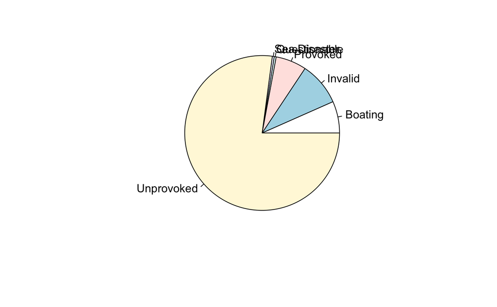

```r
pie(relative_table)
```

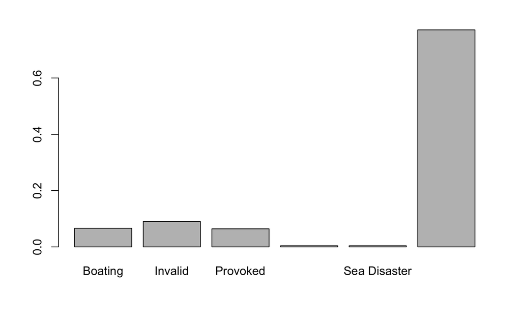

```r
barplot(relative_table)
```

### Exploración de Variables Cuantitativas (discretas)

Podemos hacer todas las que hicimos para cualitativas, pero podemos añadir ahora el histograma y la ojiva

```r
absolute_table <- table(sharks$Year)
relative_table <- prop.table(absolute_table)
```

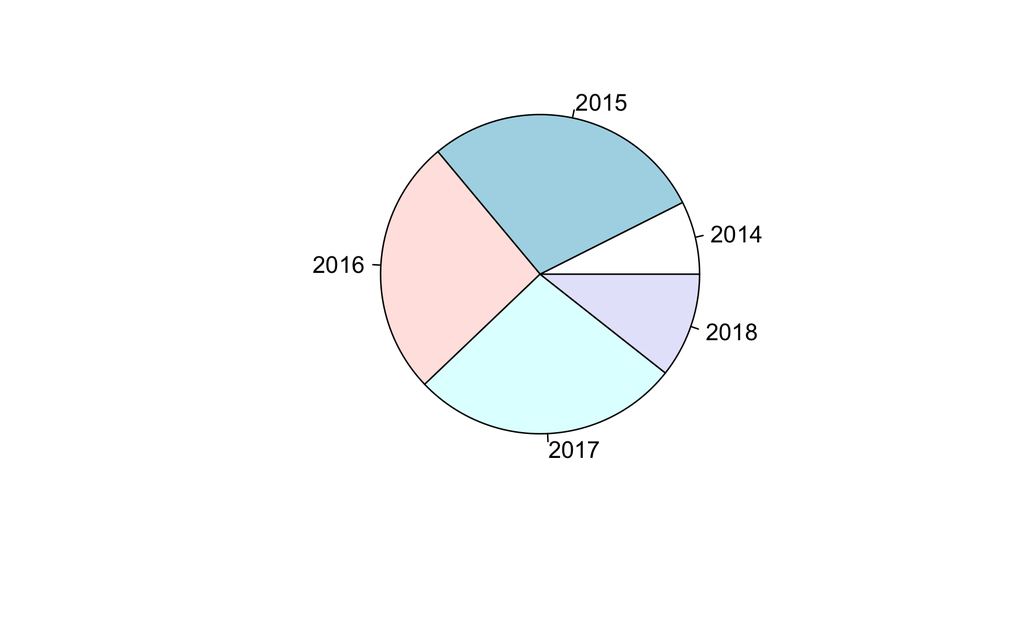

```r
pie(relative_table)
```

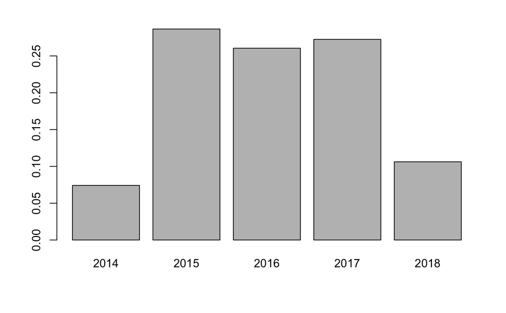

```r
barplot(relative_table)
```

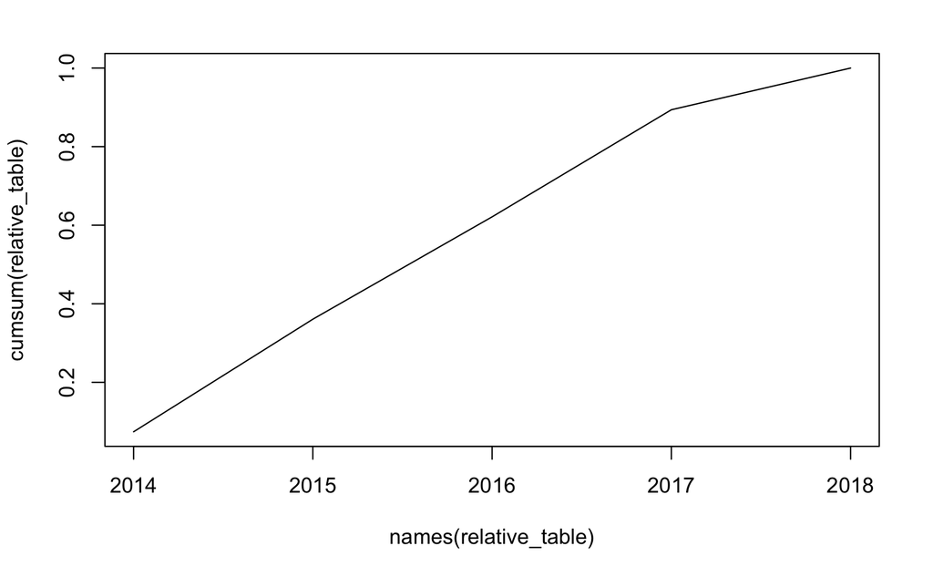

```r
plot(x = names(relative_table), y = cumsum(relative_table), type = "l")
```

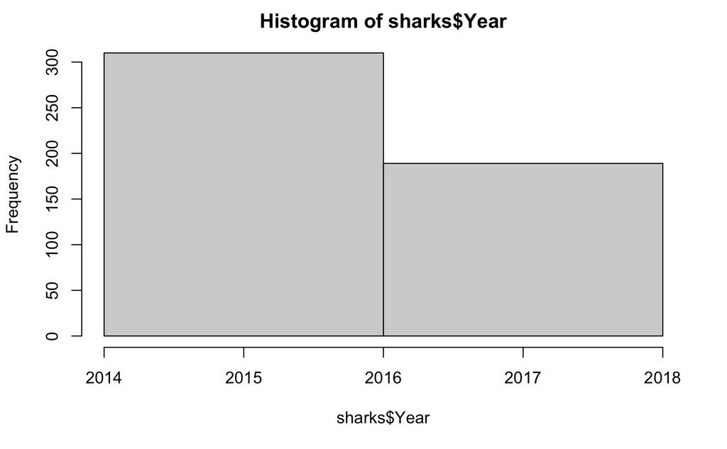

```r
hist(sharks$Year,breaks = 2)
```

### Exploración de Variables Cuantitativas (continuas)

Ya no podemos realizar un pie ni barras por que no tenemos variable discreta, pero si podemos realizar histogramas y distribuciones continuas

```
NAs introduced by coercion
```

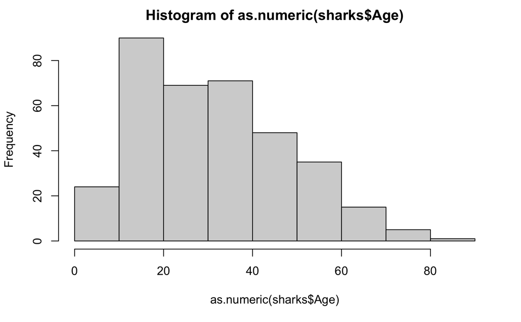

```r
hist(as.numeric(sharks$Age))
```

```r
dens <- density(as.numeric(sharks$Age), na.rm = T)
```

```
NAs introduced by coercion
```

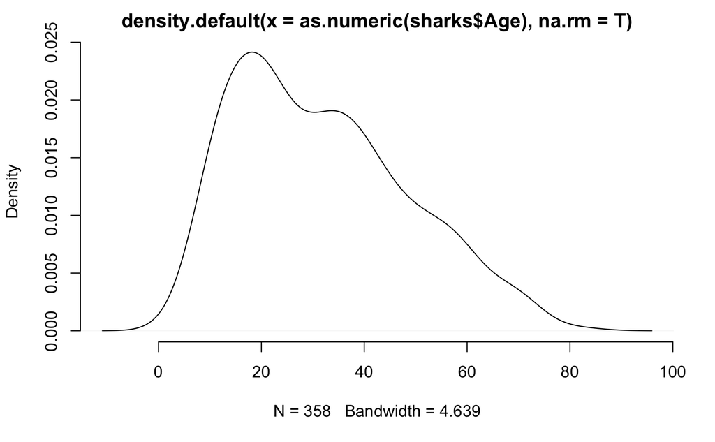

```r
plot(dens, frame = FALSE)
```